# W1: Intro to Computing

## Welcome!

[figure not shown]

Please [sign-up for an account at Posit Cloud](https://login.posit.cloud/register) and accept our classroom invitation here: https://posit.cloud/spaces/778567/join?access_code=cHS7GvIehPSq0Nwv__F1a84dieZtKLKs0lajQWyC.

## Introductions

- Who am I?
- What is [DaSL](https://hutchdatascience.org/) / [OCDO](https://ocdo.fredhutch.org/) ?
- Who are you?
  - Name, pronouns, group you work in
  - What you want to get out of the class
  - Something that is sprouting for you in the spring!
- Our wonderful TA!

## Goals of the course

- Fundamental concepts in programming languages: *How do programs run, and how do we solve problems effectively using functions and data structures?*
- Data science fundamentals: *How do you translate your scientific question to a data wrangling problem and answer it?*

## Content of the course

1. Intro to Computing
2. Data structures
3. Data wrangling 1
4. Data wrangling 2
5. Data visualization
6. Wrap-up, Pizza!

## Culture of the course

- Challenge: We are learning a new language, but you already have a full-time job.
- *Teach not for mastery, but teach for empowerment to learn effectively.*
- *Teach at learner’s pace.*

## Culture of the course

- Challenge: We sometimes struggle with our data science problems in isolation, unaware that other folks are working on similar things.
- *We learn and work better with our peers.*
- *We encourage discussion and questions, as others often have similar questions also.*

## Format of the course

- Hybrid, and recordings will be available.
- 1 hour exercises after each session are encouraged for practice.
- Office hours 11:30-Noon before class.

## Badge of completion

[figure not shown]

We offer a [badge of completion](https://www.credly.com/org/fred-hutch/badge/intro-to-r) when you finish the course!

What it is:

- A display of what you accomplished in the course, shareable in your professional networks such as LinkedIn, similar to online education services such as Coursera.

What it isn’t:

- Accreditation through an university or degree-granting program.

Requirements:

- Complete badge-required sections of the exercises for 4 out of 5 assignments.

## Ready?

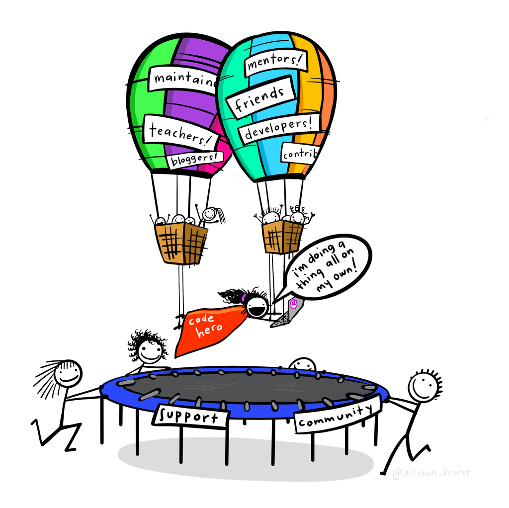

## What is a computer program?

- A *sequence* of instructions to manipulate data for the computer to execute.
- A series of *translations*: English <-> Programming Code for R Console <-> Machine Code

For example:

```r
library(tidyverse)
iris_filtered = filter(iris, Sepal.Width > 2)
mean(iris_filtered$Sepal.Width)
```

```
[1] 3.06443
```

## Setting up Posit Cloud and trying out your first analysis!

[Classroom link here.](https://posit.cloud/spaces/778567/join?access_code=cHS7GvIehPSq0Nwv__F1a84dieZtKLKs0lajQWyC)

Open up “Week 1 Classwork” once you are in the classroom.

Then open up “KRAS.qmd” document in the file browser in the right bottom corner.

## Break

Pre-course survey here: https://forms.gle/puE8W5BeYyTYJjdm8

## Grammar Structure 1: Evaluation of Expressions

Consider the expression:

```r
max(18, 21)
```

```
[1] 21
```

- **Expressions** are built out of **functions** or **operations**.
- Functions and operations take in **data types** as inputs, and **return** another data type as output.
- If the function or operation input contains expressions, evaluate those expressions first.

## Examples

```r
18 + 21
```

```
[1] 39
```

```r
max(18, 21)
```

```
[1] 21
```

```r
max(18 + 21, 65)
```

```
[1] 65
```

Parenthesis changes the order of operation:

```r
18 * (21 + 65)
```

```
[1] 1548
```

Compare with:

```r
(18 * 21) + 65
```

```
[1] 443
```

What’s this?

```r
nchar("ATCG")
```

```
[1] 4
```

## Interpreting functions and operations

- To use a function or operation, we only need to know what the expected inputs and outputs are. The inner workings doesn’t matter - it is modular.
- A function or operation can have different kinds of inputs and outputs - it doesn’t need to be numbers.

## Data types

- **Numeric**: 18, -21, 65, 1.25
- **Character**: “ATCG”, “Whatever”, “948-293-0000”
- **Logical**: TRUE, FALSE

## Grammar Structure 2: Storing variables in the environment

To build up a computer program, we need to store our returned data type from our expression somewhere for downstream use.

```r
age = 18 + 21
```

Evaluate the expression to the right of `=`.

Bind variable on the left of `=` to the resulting value.

Then the variable is stored in the **environment**.

## Downstream

Look, now `age` can be reused downstream:

```r
age - 2
```

```
[1] 37
```

```r
age_double = age * 2
age_double
```

```
[1] 78
```

`age_double` depends on `age`, so the order of code run matters.

What’s the data type of a variable?

```r
class(age_double)
```

```
[1] "numeric"
```

## More practice

```r
(sqrt(nchar("hello")) + 4) * (2 + 4)
```

```
[1] 37.41641
```

```r
brothers_age = 45
grandmas_age = 90
age = max(brothers_age, grandmas_age)
secret = (nchar("hello") + age) * (2 + 4)
secret
```

```
[1] 570
```

```r
brothers_age = brothers_age + 1
grandmas_age = grandmas_age + 1
```

## Tips on writing your first code

`Computer = powerful + stupid`

- Break down complex expressions: if `my_function(a, b + c)` isn’t working, examine `a` and `b + c`
- The sequence of instructions you give matters! Refresh the page, or click the broom button, to clear the environment.
- **Ask for help!**